# Data Mining - XGBoost Python Demonstration

#### PowerPoint and datasets provided by Dr. Nydick

## Setup

This demonstration was performed using Python in a Jupyter Notebook file. These files allow for interspersing cells of interactive code with formatted text, visualizations, and equations.

To begin, I imported the required Python packages. These are prebuilt collections of code that can be imported into any Python file, and they are widely used for data analysis. They are given aliases, such as 'np' for NumPy, which offers convenience when typing.

In this project, I used:

- Graphviz - Graph visualization software, needed for XGBoost's plotting functions.
- NumPy - Provides support for arrays and matricies
- pandas - Builds off Numpy, provides dataframes (tables), which are fast and easy to use data structures.
- matplotlib - Basic 2D data visualizations, in the style of MATLAB.
- Scikit-Learn - Provides simple machine learning and data preprocessing tools for data mining.
- SciPy - Mathematical algorithms used for scientific computing, built off NumPy
- XGBoost - Python implementation of the XGBoost algorithm.

While importing the packages, I set the display options for matplotlib.

```python
import numpy as np
import pandas as pd
import xgboost as xgb

from xgboost import XGBClassifier

from scipy.stats import randint, uniform

from sklearn import metrics
from sklearn import model_selection

import graphviz
import matplotlib.pyplot as plt
%matplotlib inline
from matplotlib import rcParams
rcParams["figure.figsize"] = (30, 20)
```

## Loading the Data and Preparing it for Analysis

Next, I exported the training dataset from JMP to Excel and saved it as a .CSV. It was loaded into a dataframe using pandas, with the "ID" column as the index. A dataframe is a data structure akin to a spreadsheet or table. To examine the training dataset, I called the .head() method off of the 'training_dataset' dataframe object. A method is a function that belongs to a type of object. The .head() method prints the first 5 records of the dataset.

After that, I looped through all the categorical variables, printing out the unique values and the count of each category. The XGBoost algorithm cannot handle categorical variables, so I needed handle them with binary encoding. This was done by calling the get_dummies() function on the training_dataset object.

I reset the order of the columns to have Claim and Claim Amount last. This was purely cosmetic, having no effect on the analysis. To examine the cleaned training dataset, I called the .head() method on the object.

```python
file_path = "C:\\Users\\drewi\\Desktop\\XGBoost\\auto insurance XGBoost (training & validation).csv"
training_dataset = pd.read_csv(file_path, index_col=0)
training_dataset.drop(["Validation"], axis = 1, inplace=True) # Dropping Validation column since it's not used
print(training_dataset.head())

print("\n") # Printing a newline
print("Count of values for the categorical variables:")
categorical_variables = training_dataset[["Gender", "Education", "Recent Claim", "Coverage Type"]]
for cols in categorical_variables:
    print(categorical_variables[cols].unique())
    print(categorical_variables[cols].value_counts())
    print("\n")
training_dataset = pd.get_dummies(training_dataset)
# Resetting order of columns so Claim and Claim Amount are at the end
training_dataset = training_dataset[['Age', 'Income', 'Premium', 'Vehicle Age', 'Vehicle Value',
                                     'Age Imputed', 'Income Imputed', 'Gender_f',
                                     'Gender_m', 'Gender_o', 'Education_Doctorate', 'Education_Graduate',
                                     'Education_HS', 'Education_Undergraduate', 'Education_no diploma',
                                     'Recent Claim_n', 'Recent Claim_y', 'Coverage Type_collision',
                                     'Coverage Type_comprehensive', 'Coverage Type_liability', 'Claim', 'Claim Amount']]
training_dataset.head()
```

```
     Age Gender      Education    Income Recent Claim  Premium  Coverage Type  \
ID
2   39.0      f  Undergraduate   99000.0            n      615      liability
4   56.0      m  Undergraduate  233000.0            y     2098  comprehensive
5   19.0      m             HS       NaN            n     1666      liability
7   77.0      f             HS   13000.0            n      500      liability
8   67.0      f             HS   37000.0            n     1311  comprehensive

    Vehicle Age  Vehicle Value  Age Imputed  Income Imputed  Claim  \
ID
2            14          13000         39.0     99000.00000      0
4             4          31000         56.0    233000.00000      0
5            12           2000         19.0     22800.57494      0
7             6           5000         77.0     13000.00000      0
8             1          27000         67.0     37000.00000      0

    Claim Amount
ID
2              0
4              0
5              0
7              0
8              0


Count of values for the categorical variables:
['f' 'm' 'o']
m    4511
f    4473
o      16
Name: Gender, dtype: int64


['Undergraduate' 'HS' 'Graduate' 'no diploma' 'Doctorate' nan]
HS               5231
Undergraduate    1540
no diploma        939
Graduate          703
Doctorate         227
Name: Education, dtype: int64


['n' 'y' nan]
n    5309
y    3202
Name: Recent Claim, dtype: int64


['liability' 'comprehensive' 'collision']
collision        4516
liability        3089
comprehensive    1395
Name: Coverage Type, dtype: int64
```

| ID | Age | Income | Premium | Vehicle Age | Vehicle Value | Age Imputed | Income Imputed | Gender_f | Gender_m | Gender_o | ... | Education_HS | Education_Undergraduate | Education_no diploma | Recent Claim_n | Recent Claim_y | Coverage Type_collision | Coverage Type_comprehensive | Coverage Type_liability | Claim | Claim Amount |
| --- | --- | --- | --- | --- | --- | --- | --- | --- | --- | --- | --- | --- | --- | --- | --- | --- | --- | --- | --- | --- | --- |
| 2 | 39.0 | 99000.0 | 615 | 14 | 13000 | 39.0 | 99000.00000 | 1 | 0 | 0 | ... | 0 | 1 | 0 | 1 | 0 | 0 | 0 | 1 | 0 | 0 |
| 4 | 56.0 | 233000.0 | 2098 | 4 | 31000 | 56.0 | 233000.00000 | 0 | 1 | 0 | ... | 0 | 1 | 0 | 0 | 1 | 0 | 1 | 0 | 0 | 0 |
| 5 | 19.0 | NaN | 1666 | 12 | 2000 | 19.0 | 22800.57494 | 0 | 1 | 0 | ... | 1 | 0 | 0 | 1 | 0 | 0 | 0 | 1 | 0 | 0 |
| 7 | 77.0 | 13000.0 | 500 | 6 | 5000 | 77.0 | 13000.00000 | 1 | 0 | 0 | ... | 1 | 0 | 0 | 1 | 0 | 0 | 0 | 1 | 0 | 0 |
| 8 | 67.0 | 37000.0 | 1311 | 1 | 27000 | 67.0 | 37000.00000 | 1 | 0 | 0 | ... | 1 | 0 | 0 | 1 | 0 | 0 | 1 | 0 | 0 | 0 |

5 rows × 22 columns

### Loading in the Test Set

Preparation for the test dataset was in an identical manner to that of training dataset. Once the test dataset was prepared, I split it up into X and Y variables.

The last line of the cell below converted the predictor variables from the test dataset to a more memory efficient data structure. It had no discernable effect on performance, but adding that line suppressed a warning from XGBoost.

```python
file_path = "C:\\Users\\drewi\\Desktop\\XGBoost\\auto insurance XGBoost (test).csv"
test_dataset = pd.read_csv(file_path, index_col=0)
test_dataset.drop(["Validation"], axis = 1, inplace=True) # Dropping Validation column

test_dataset = pd.get_dummies(test_dataset)

# Resetting order of columns so Claim Amount and Claim are at the end
test_dataset = test_dataset[['Age', 'Income', 'Premium', 'Vehicle Age', 'Vehicle Value',
                                     'Age Imputed', 'Income Imputed', 'Gender_f',
                                     'Gender_m', 'Gender_o', 'Education_Doctorate', 'Education_Graduate',
                                     'Education_HS', 'Education_Undergraduate', 'Education_no diploma',
                                     'Recent Claim_n', 'Recent Claim_y', 'Coverage Type_collision',
                                     'Coverage Type_comprehensive', 'Coverage Type_liability',
                                     'Claim Amount', 'Claim']]

X_test = test_dataset.drop(["Claim", "Claim Amount"], axis=1)
Y_test = test_dataset[["Claim"]]

X_test = np.ascontiguousarray(X_test) # Reduces memory usage
```

### Cross-Validation

Next, I assigned the variable 'random_seed' the value 5. Whenever possible, I used that random seed to replicate the results of the PowerPoint as closely as possible. To align with JMP's built-in K-Fold cross-validation for XGBoost, I created a RepeadedStratefiedKFold object from the sklearn module. It was created with 5 folds per repetition and 3 repetitions, like in the PowerPoint.

```python
random_seed = 5
k_fold = model_selection.RepeatedStratifiedKFold(n_splits=5, n_repeats=3, random_state=random_seed)
```

### Fitting the Model to the Data

With the datasets and cross-validator prepared, I began to fit the create the XGBoost model and fit it to the data. I separated the training dataset into regressor and response variables, as instructed by slide 23 of the PowerPoint. The parameters used for the model are the default values. I explicitly stated them to demonstrate that I was using the same values as the PowerPoint.

There were two parameters of the model that were not present on slide 24 of the PowerPoint. The "use_label_encoder" parameter was set to False, because I created my own dummy columns and did not need to use the built-in label encoder.

The "scale_pos_weight" parameter controls the balance of positive and negative weights. It is useful for an unbalanced dataset, such as this one, where the relative number of positive classifications is small compared to that of negative classifications. The documentation suggests starting with the ratio of negative classifications to positive classifications in the dependent variable. I calculated this as 7.42, which I rounded to the nearest integer (7). When I didn't use this parameter, the model predicted far too few positives for Claim. Therefore, I suspect JMP has implemented something similar under the hood.

After creating the model, I fit it to the training data.

```python
regressors = training_dataset.drop(["Claim", "Claim Amount"], axis=1)
response = training_dataset["Claim"]


model = XGBClassifier(max_depth=6, subsample=1, colsample_bytree=1,
                      min_child_weight=1, reg_alpha=0, reg_lambda=1, learning_rate=0.3,
                      n_estimators=100, random_state=random_seed, eval_metric="rmse",
                      scale_pos_weight=7, use_label_encoder=False)

model.fit(regressors, response)
```

```
XGBClassifier(base_score=0.5, booster='gbtree', colsample_bylevel=1,
              colsample_bynode=1, colsample_bytree=1, eval_metric='rmse',
              gamma=0, gpu_id=-1, importance_type='gain',
              interaction_constraints='', learning_rate=0.3, max_delta_step=0,
              max_depth=6, min_child_weight=1, missing=nan,
              monotone_constraints='()', n_estimators=100, n_jobs=4,
              num_parallel_tree=1, random_state=5, reg_alpha=0, reg_lambda=1,
              scale_pos_weight=7, subsample=1, tree_method='exact',
              use_label_encoder=False, validate_parameters=1, verbosity=None)
```

### Parameter Tuning

To replicate the hyperparameter tuning in JMP, I created a RandomizedSearchCV object, "tuned_model", from sklearn. All of the parameters were stored in a dictionary, which is a Python data structure that holds key-value pairs. The keys were the name of the parameters, and the values were statistical distribution provided by SciPy. The randint() function creates a discrete uniform distribution from the start to the stop parameter, and uniform() creates a continuous uniform distribution over the parameters start and start+value. For example, uniform(0.3, 0.7) created a continuous uniform distribution from 0.3 to 1.0.

I set the tuned_model to run 20 iterations of the randomized hyperparameter search, selecting the model with the best RMSE. For cross-validation, I passed "tuned_model" the "k_fold" object I created earlier. The hyperparameter search was instructed to use all CPU cores via the "n_jobs=-1" parameter.

```python
np.random.RandomState(5)
params = {
    "max_depth": randint(3, 9),
    "subsample": uniform(0.3, 0.7),
    "colsample_bytree": uniform(0.3, 0.7),
    "min_child_weight": randint(1, 10),
    "reg_alpha":  uniform(0, 2),
    "reg_lambda":  uniform(0, 2),
    "learning_rate": uniform(0.05, 0.25),
    "n_estimators": randint(20, 200)
}


tuned_model = model_selection.RandomizedSearchCV(model, param_distributions=params, n_iter=20,
                                                 cv=k_fold, random_state=5,
                                                 scoring="neg_root_mean_squared_error", n_jobs=-1)


tuned_model.fit(regressors, response)
print("Best Parameters:", tuned_model.best_params_)

test_preds = tuned_model.predict(X_test)
print("RMSE of best iteration:", metrics.mean_squared_error(Y_test, test_preds, squared=False))
```

```
Best Parameters: {'colsample_bytree': 0.8903626847688868, 'learning_rate': 0.20403120782772655, 'max_depth': 8, 'min_child_weight': 4, 'n_estimators': 144, 'reg_alpha': 1.2795903522617142, 'reg_lambda': 1.9712488056083777, 'subsample': 0.481368317487774}
RMSE of best iteration: 0.4449719092257398
```

### Concatenating the Datasets

With the tuned model obtained, I could concatenate the training and test datasets. This was done using the concat() function from pandas. Then, I predicted Claim values for the concatenated dataset with the tuned model. The RMSE was recalculated by comparing the Claim value of the combined dataset to the predicted values. Naturally, the new score was much lower, since the training portion of the data was included in the evaluation.

```python
concatenated_dataset = pd.concat([training_dataset, test_dataset])

X_concatenated = concatenated_dataset.drop(["Claim", "Claim Amount"], axis=1)
X_concatenated = np.ascontiguousarray(X_concatenated) # Reduces memory usage
preds = tuned_model.predict(X_concatenated)

print("RMSE:", metrics.mean_squared_error(concatenated_dataset[["Claim"]], preds, squared=False))
concatenated_dataset
```

```
RMSE: 0.2659887215654077
```

| ID | Age | Income | Premium | Vehicle Age | Vehicle Value | Age Imputed | Income Imputed | Gender_f | Gender_m | Gender_o | ... | Education_HS | Education_Undergraduate | Education_no diploma | Recent Claim_n | Recent Claim_y | Coverage Type_collision | Coverage Type_comprehensive | Coverage Type_liability | Claim | Claim Amount |
| --- | --- | --- | --- | --- | --- | --- | --- | --- | --- | --- | --- | --- | --- | --- | --- | --- | --- | --- | --- | --- | --- |
| 2 | 39.0 | 99000.0 | 615 | 14 | 13000 | 39.000000 | 99000.00000 | 1 | 0 | 0 | ... | 0 | 1 | 0 | 1 | 0 | 0 | 0 | 1 | 0 | 0 |
| 4 | 56.0 | 233000.0 | 2098 | 4 | 31000 | 56.000000 | 233000.00000 | 0 | 1 | 0 | ... | 0 | 1 | 0 | 0 | 1 | 0 | 1 | 0 | 0 | 0 |
| 5 | 19.0 | NaN | 1666 | 12 | 2000 | 19.000000 | 22800.57494 | 0 | 1 | 0 | ... | 1 | 0 | 0 | 1 | 0 | 0 | 0 | 1 | 0 | 0 |
| 7 | 77.0 | 13000.0 | 500 | 6 | 5000 | 77.000000 | 13000.00000 | 1 | 0 | 0 | ... | 1 | 0 | 0 | 1 | 0 | 0 | 0 | 1 | 0 | 0 |
| 8 | 67.0 | 37000.0 | 1311 | 1 | 27000 | 67.000000 | 37000.00000 | 1 | 0 | 0 | ... | 1 | 0 | 0 | 1 | 0 | 0 | 1 | 0 | 0 | 0 |
| ... | ... | ... | ... | ... | ... | ... | ... | ... | ... | ... | ... | ... | ... | ... | ... | ... | ... | ... | ... | ... | ... |
| 11989 | 62.0 | 27000.0 | 1025 | 2 | 11000 | 62.000000 | 27000.00000 | 0 | 1 | 0 | ... | 1 | 0 | 0 | 1 | 0 | 0 | 0 | 1 | 0 | 0 |
| 11992 | NaN | 2000.0 | 2193 | 0 | 18000 | 41.242269 | 2000.00000 | 1 | 0 | 0 | ... | 1 | 0 | 0 | 1 | 0 | 1 | 0 | 0 | 0 | 0 |
| 11993 | 21.0 | 24000.0 | 2665 | 0 | 25000 | 21.000000 | 24000.00000 | 0 | 1 | 0 | ... | 1 | 0 | 0 | 0 | 1 | 0 | 1 | 0 | 0 | 0 |
| 11999 | 25.0 | 64000.0 | 1458 | 0 | 36000 | 25.000000 | 64000.00000 | 1 | 0 | 0 | ... | 1 | 0 | 0 | 1 | 0 | 0 | 1 | 0 | 0 | 0 |
| 12000 | 60.0 | 48000.0 | 1282 | 21 | 2000 | 60.000000 | 48000.00000 | 0 | 1 | 0 | ... | 1 | 0 | 0 | 1 | 0 | 0 | 0 | 1 | 0 | 0 |

12000 rows × 22 columns

### Plotting the Tree and Feature Importance

#### Decision Tree

Such a large tree is difficult to visually inspect, so I saved it as "XGBoost Tree.png" and attached it for your convenience.

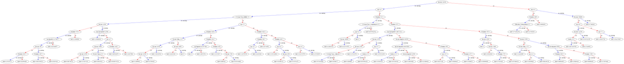

```python
fig, ax = plt.subplots(figsize=(200, 500))
xgb.plot_tree(tuned_model.best_estimator_, ax=ax)
fig.savefig('XGBoost Tree.png')
plt.show()
```

#### Feature Importance

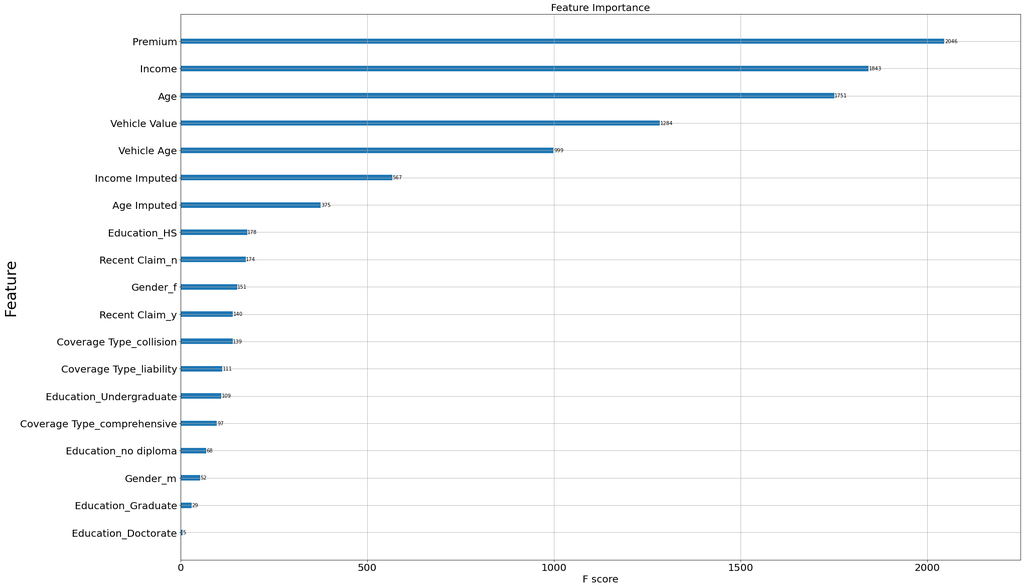

```python
xgb.plot_importance(tuned_model.best_estimator_)
plt.yticks(size=20)
plt.xticks(size=20)
plt.xlabel('F score', size=20)
plt.ylabel('Feature', size=30)
plt.title("Feature Importance", size=20)
plt.show()
```

### Profit Maximization

The final section of the data analysis was the profit evaluation.

#### Profit Table

First, I assembled the profit table, which is columns AY:BG on the solution file. An empty DataFrame object object "profit_table" was created, with the same index as the concatenated dataset. The columns all used the same names as the ones in the solution PowerPoint. I filled in their values according to the following expressions:

- Claim Predictor - Using the .predict_proba() method on the "tuned_model", return the probability of Claim = 1
- Probability(Claim==0) - Using the .predict_proba() method on the "tuned_model", return the probability of Claim = 0
- Profit for pred 0 - (1878 *Probability(Claim==0) + -11485* Claim Predictor)
- Profit for pred 1 - (0 *Probability(Claim==0) + 0* Claim Predictor)
- Prediction - The predicted values of the concatenated dataset created by the model.
- Prediction=0, Actual=0 - The where() function, part of NumPy, has a very similar syntax to the IF function in Excel. The values in this column and the next three were filled by checking a condition, the first argument in the function. If the condition was true, then the value would be a 1, else a 0. The & symbol is an operator that will evaluate the conditions surrounding it and return true if both of them are true. The == symbol means equal to. This column filled in the row with a 1 if both Prediction and Claim were 0, otherwise the row would be filled in with a 0.
- Prediction=1, Actual=0 - If Prediction equals 1 and Claim equals 0, then fill in a 1, otherwise a 0.
- Prediction=0, Actual=1 - If Prediction equals 0 and Claim equals 1, then fill in a 1, otherwise a 0.
- Prediction=1, Actual=1 - If Prediction equals 1 and Claim equals 1, then fill in a 1, otherwise a 0.

```python
profit_table = pd.DataFrame(index=concatenated_dataset.index,
                            columns=["Claim Predictor", "Probability(Claim==0)", "Profit for pred 0",
                                     "profit for pred 1", "Prediction", "Prediction=0, Actual=0",
                                     "Prediction=1, Actual=0", "Prediction=0, Actual=1", "Prediction=1, Actual=1"])

profit_table["Claim Predictor"] = tuned_model.predict_proba(X_concatenated)[:, 1]
profit_table["Probability(Claim==0)"] = tuned_model.predict_proba(X_concatenated)[:, 0]
profit_table["Profit for pred 0"] = 1878 * profit_table["Probability(Claim==0)"] + -11485 * profit_table["Claim Predictor"]
profit_table["Profit for pred 1"] = 0 * profit_table["Probability(Claim==0)"] + 0 * profit_table["Claim Predictor"]
profit_table["Prediction"] = preds
profit_table["Prediction=0, Actual=0"] = np.where(((profit_table["Prediction"]==0) & (concatenated_dataset["Claim"]==0)),1,0)
profit_table["Prediction=1, Actual=0"] = np.where(((profit_table["Prediction"]==1) & (concatenated_dataset["Claim"]==0)),1,0)
profit_table["Prediction=0, Actual=1"] = np.where(((profit_table["Prediction"]==0) & (concatenated_dataset["Claim"]==1)),1,0)
profit_table["Prediction=1, Actual=1"] = np.where(((profit_table["Prediction"]==1) & (concatenated_dataset["Claim"]==1)),1,0)

profit_table
```

| ID | Claim Predictor | Probability(Claim==0) | Profit for pred 0 | profit for pred 1 | Prediction | Prediction=0, Actual=0 | Prediction=1, Actual=0 | Prediction=0, Actual=1 | Prediction=1, Actual=1 | Profit for pred 1 |
| --- | --- | --- | --- | --- | --- | --- | --- | --- | --- | --- |
| 2 | 0.011767 | 0.988233 | 1720.754517 | NaN | 0 | 1 | 0 | 0 | 0 | 0.0 |
| 4 | 0.015870 | 0.984130 | 1665.922852 | NaN | 0 | 1 | 0 | 0 | 0 | 0.0 |
| 5 | 0.263163 | 0.736837 | -1638.645630 | NaN | 0 | 1 | 0 | 0 | 0 | 0.0 |
| 7 | 0.064006 | 0.935994 | 1022.692017 | NaN | 0 | 1 | 0 | 0 | 0 | 0.0 |
| 8 | 0.001167 | 0.998833 | 1862.409668 | NaN | 0 | 1 | 0 | 0 | 0 | 0.0 |
| ... | ... | ... | ... | ... | ... | ... | ... | ... | ... | ... |
| 11989 | 0.023951 | 0.976049 | 1557.944458 | NaN | 0 | 1 | 0 | 0 | 0 | 0.0 |
| 11992 | 0.107868 | 0.892132 | 436.558105 | NaN | 0 | 1 | 0 | 0 | 0 | 0.0 |
| 11993 | 0.019382 | 0.980618 | 1619.004639 | NaN | 0 | 1 | 0 | 0 | 0 | 0.0 |
| 11999 | 0.464131 | 0.535869 | -4324.186035 | NaN | 0 | 1 | 0 | 0 | 0 | 0.0 |
| 12000 | 0.237095 | 0.762905 | -1290.305908 | NaN | 0 | 1 | 0 | 0 | 0 | 0.0 |

12000 rows × 10 columns

#### Profit Matrix

To fill in the profit values for each cell in the profit matrix, I accessed their indexed location using the .iloc property of a dataframe, and assigned the corresponding value from the solution file. The indexing of the .iloc property starts at 0 and the order of the axes passed is rows then columns. Therefore, the element 'profit_matrix.iloc[1, 0]' is in the 2nd row and the first column. I named the rows and columns of the dataframe to assist in identifying which profit value is mapped to which combination of actual and predicted classification.

```python
profit_matrix = pd.DataFrame(index=["Actually Negative", "Actually Positive"],
                               columns=["Predicted Negative", "Predicted Positive"])

profit_matrix.iloc[0, 0] = 1878
profit_matrix.iloc[0, 1] = 0
profit_matrix.iloc[1, 1] = 0
profit_matrix.iloc[1, 0] = -11485
profit_matrix
```

|  | Predicted Negative | Predicted Positive |
| --- | --- | --- |
| Actually Negative | 1878 | 0 |
| Actually Positive | -11485 | 0 |

#### Decision Matrix

The names of the rows and columns in the 'decision_matrix' dataframe were the same as the ones in 'profit_matrix'. Like the previous step, I accessed each element in the dataframe using the iloc property, and assigned it a value that corresponded to the count of each combination of actual and predicted classification. To count the totals, I called the sum() function on rows 9000 through 12000 of each of the last 4 columns in 'profit_table'.

```python
decision_matrix = pd.DataFrame(index=["Actually Negative", "Actually Positive"],
                               columns=["Predicted Negative", "Predicted Positive"])

decision_matrix.iloc[0, 0] = sum(profit_table["Prediction=0, Actual=0"].iloc[9000:120001])
decision_matrix.iloc[0, 1] = sum(profit_table["Prediction=0, Actual=1"].iloc[9000:120001])
decision_matrix.iloc[1, 1] = sum(profit_table["Prediction=1, Actual=1"].iloc[9000:120001])
decision_matrix.iloc[1, 0] = sum(profit_table["Prediction=1, Actual=0"].iloc[9000:120001])
decision_matrix
```

|  | Predicted Negative | Predicted Positive |
| --- | --- | --- |
| Actually Negative | 2344 | 312 |
| Actually Positive | 282 | 62 |

#### Profit

The final step in the analysis was to calculate the total profit for the test set and profit for test set row. First, I created an array called 'profit' by multiplying the values in the 'decision_matrix' by those in the 'profit_matrix'.

Then I printed the total profit by calling the .sum() method on 'profit' and inserted the result into a formatted string. Lastly, to print the profit per test row, I repeated the line above but divided the sum of 'profit' by 3000. I formatted the calculation to have two decimal places to represent cents.

```python
profit = decision_matrix.values * profit_matrix.values
print(profit)
print("Total profit = ${}".format(profit.sum()))
print("Profit per test row (3000) = ${:.2f}".format(profit.sum()/3000))
```

```
[[4402032 0]
 [-3238770 0]]
Total profit = $1163262
Profit per test row (3000) = $387.75
```